# Practical Machine Learning

Sujitha P

December 20, 2018

## Introduction

Using devices such as Jawbone Up, Nike FuelBand, and Fitbit it is now possible to collect a large amount of data about personal activity relatively inexpensively. These type of devices are part of the quantified self movement - a group of enthusiasts who take measurements about themselves regularly to improve their health, to find patterns in their behavior, or because they are tech geeks. One thing that people regularly do is quantify how much of a particular activity they do, but they rarely quantify how well they do it. In this project, your goal will be to use data from accelerometers on the belt, forearm, arm, and dumbell of 6 participants. They were asked to perform barbell lifts correctly and incorrectly in 5 different ways. More information is available from the website here: http://web.archive.org/web/20161224072740/http:/groupware.les.inf.puc-rio.br/har (see the section on the Weight Lifting Exercise Dataset).

## Source Of Data

The training data for this project are available here:

https://d396qusza40orc.cloudfront.net/predmachlearn/pml-training.csv

The test data are available here:

https://d396qusza40orc.cloudfront.net/predmachlearn/pml-testing.csv

The data for this project come from this source: http://groupware.les.inf.puc-rio.br/har. If you use the document you create for this class for any purpose please cite them as they have been very generous in allowing their data to be used for this kind of assignment.

## Data Processing

```r
library(caret)
```

```r
library(rpart)
library(rpart.plot)
library(RColorBrewer)
library(rattle)
library(randomForest)
# Load the training dataset
dt_training <- read.csv("pml-training.csv", na.strings=c("NA",""), strip.white=T)

# Load the testing dataset
dt_testing <- read.csv("pml-testing.csv", na.strings=c("NA",""), strip.white=T)
```

## Data Cleaning

```r
features <- names(dt_testing[,colSums(is.na(dt_testing)) == 0])[8:59]

# Only use features used in testing cases.
dt_training <- dt_training[,c(features,"classe")]
dt_testing <- dt_testing[,c(features,"problem_id")]

dim(dt_training)
```

```
## [1] 19622    53
```

```r
dim(dt_testing)
```

```
## [1] 20 53
```

## Partitioning the Dataset

```r
set.seed(1234567)

inTrain <- createDataPartition(dt_training$classe, p=0.6, list=FALSE)
training <- dt_training[inTrain,]
testing <- dt_training[-inTrain,]

dim(training)
```

```
## [1] 11776    53
```

```r
dim(testing)
```

```
## [1] 7846   53
```

## Decision Tree Model

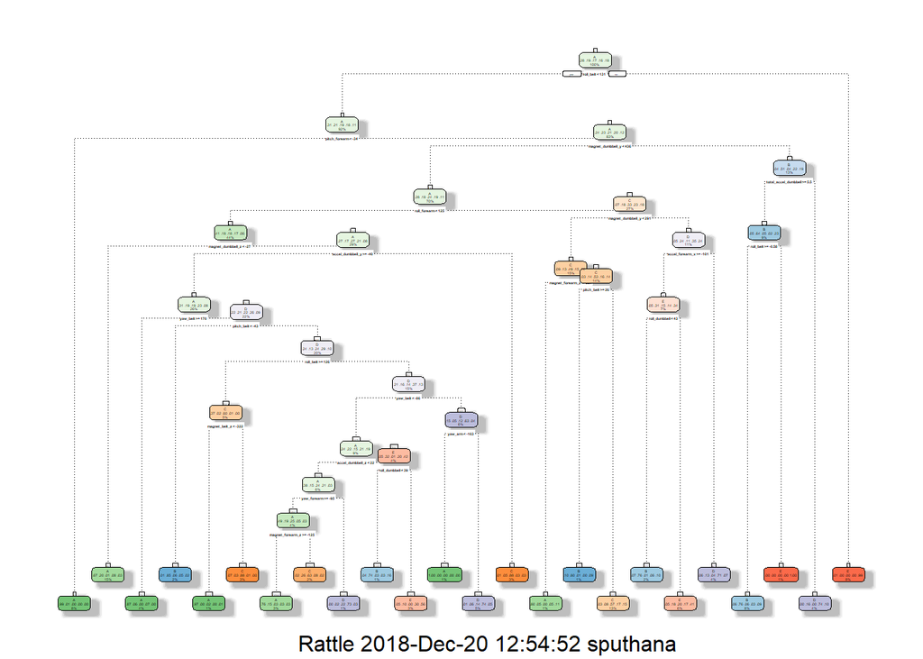

```r
modFitDT <- rpart(classe ~ ., data = training, method="class")
fancyRpartPlot(modFitDT)
```

## Predicting with the Decision Tree Model

```r
set.seed(1234567)
prediction <- predict(modFitDT, testing, type = "class")
confusionMatrix(prediction, testing$class)
```

```
## Confusion Matrix and Statistics
##
##           Reference
## Prediction    A    B    C    D    E
##          A 2038  312   24  117   47
##          B   60  842   83   42   98
##          C   67  156 1105  193  181
##          D   30  105   76  800   76
##          E   37  103   80  134 1040
##
## Overall Statistics
##
##                Accuracy : 0.7424
##                  95% CI : (0.7326, 0.7521)
##     No Information Rate : 0.2845
##     P-Value [Acc > NIR] : < 2.2e-16
##
##                   Kappa : 0.6727
##  Mcnemar's Test P-Value : < 2.2e-16
##
## Statistics by Class:
##
##                      Class: A Class: B Class: C Class: D Class: E
## Sensitivity            0.9131   0.5547   0.8077   0.6221   0.7212
## Specificity            0.9109   0.9553   0.9078   0.9563   0.9447
## Pos Pred Value         0.8030   0.7484   0.6492   0.7360   0.7461
## Neg Pred Value         0.9635   0.8994   0.9572   0.9281   0.9377
## Prevalence             0.2845   0.1935   0.1744   0.1639   0.1838
## Detection Rate         0.2598   0.1073   0.1408   0.1020   0.1326
## Detection Prevalence   0.3235   0.1434   0.2169   0.1385   0.1777
## Balanced Accuracy      0.9120   0.7550   0.8578   0.7892   0.8330
```

## Building the Random Forest Model

```r
set.seed(12345)
modFitRF <- randomForest(classe ~ ., data = training, ntree = 1000)
```

## Predicting on the Testing Data

```r
predictionDT <- predict(modFitDT, dt_testing, type = "class")
predictionDT
```

```
##  1  2  3  4  5  6  7  8  9 10 11 12 13 14 15 16 17 18 19 20
##  B  A  E  A  A  C  D  A  A  A  C  E  C  A  E  E  A  A  A  B
## Levels: A B C D E
```

## Random Forest Prediction

```r
predictionRF <- predict(modFitRF, dt_testing, type = "class")
predictionRF
```

```
##  1  2  3  4  5  6  7  8  9 10 11 12 13 14 15 16 17 18 19 20
##  B  A  B  A  A  E  D  B  A  A  B  C  B  A  E  E  A  B  B  B
## Levels: A B C D E
```